# Practical Machine Learning Course Project

Analysis

Attila Doroszlai

17 Dec 2014

## Introduction

The goal of this project was to create and evaluate a classification model for the [Human Activity Recognition - Weight Lifting Exercises Dataset](http://groupware.les.inf.puc-rio.br/har#weight_lifting_exercises).

## Dataset

The dataset originally comes from *Velloso, E.; Bulling, A.; Gellersen, H.; Ugulino, W.; Fuks, H. [Qualitative Activity Recognition of Weight Lifting Exercises](http://groupware.les.inf.puc-rio.br/work.jsf?p1=11201). Proceedings of 4th International Conference in Cooperation with SIGCHI (Augmented Human ’13) . Stuttgart, Germany: ACM SIGCHI, 2013.*

In the experiment *“six … participants were asked to perform … 10 repetitions of the Unilateral Dumbbell Biceps Curl in five different fashions: exactly according to the specification (Class A),”* and in four different incorrect ways (Classes B-E).

This project works with the [training subset](https://d396qusza40orc.cloudfront.net/predmachlearn/pml-training.csv) of the data created by the course instructors.

The dataset contains 19622 observations for 160 variables. Most of the variables are raw and summarized measurements from accelerometers and other sensors placed in four different parts of the participants’ body. The rest are identifiers, timestamps, and finally *classe* is the response variable.

### Data Cleaning

The dataset needed to be cleaned prior to modelling. The cleaning process is documented in (and was performed by) `data_cleaning.Rmd` (compiled output).

All original rows were retained in the clean dataset, but only 54 variables were kept.

## Modelling

Modelling steps described below were performed by the `modelling.R` script.

The dataset was further split randomly into training and testing subsets. Only 9812 observations were used for training. The other 9810 observations were later used to estimate out-of-sample accuracy.

### Training

The model of choice for this project was **random forest**, using *classe* as the response and all 53 other variables as predictors.

Training data was preprocessed to be centered ($\mu = 0$) and scaled ($\sigma = 1$).

Several models were fitted varying the tuning parameter using the *caret* package. Random forest has a single tuning parameter *m*, the number of randomly selected predictors considered at each split of the tree, and models were built for values $m \in [2, 53]$.

The training process used 10-fold cross-validation (implemented by *caret*) to evaluate the models. See the appendix for the full fitted model.

#### Cross-Validation Accuracy vs. Number of Randomly Selected Predictors

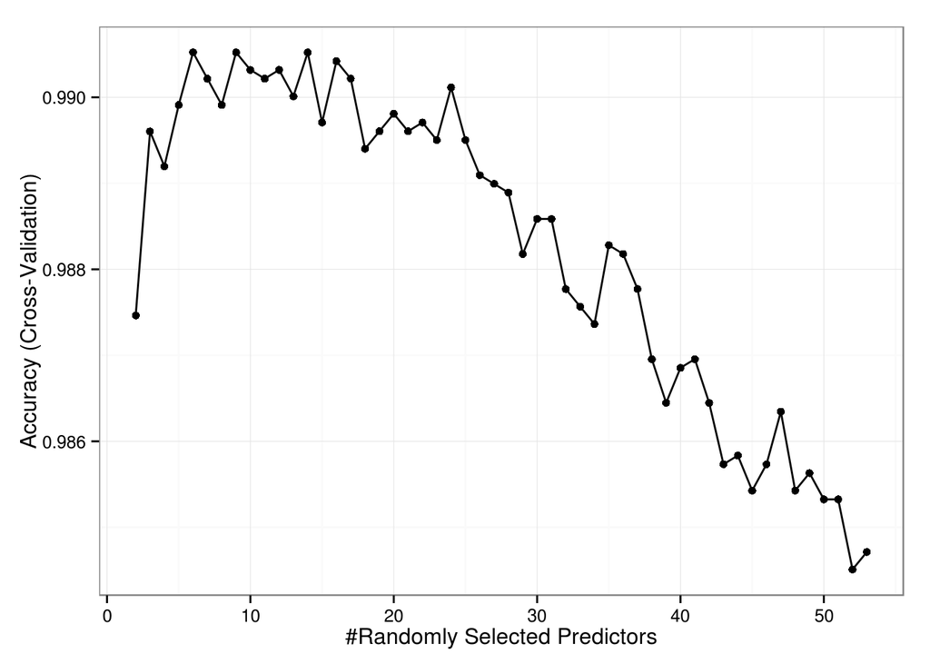

### Final Model

The random forest model with $m = 9$ was selected as the final model based on **cross-validation accuracy**: 0.9905.

### Testing

**Out-of-sample accuracy**: 0.9917 was estimated using the 9810 observations not used in the training process.

```
## Confusion Matrix and Statistics
##
##           Reference
## Prediction    A    B    C    D    E
##          A 2780   11    0    0    0
##          B    8 1886   25    0    0
##          C    0    1 1684   24    5
##          D    0    0    2 1583    2
##          E    2    0    0    1 1796
##
## Overall Statistics
##
##                Accuracy : 0.992
##                  95% CI : (0.99, 0.993)
##     No Information Rate : 0.284
##     P-Value [Acc > NIR] : <2e-16
##
##                   Kappa : 0.99
##  Mcnemar's Test P-Value : NA
##
## Statistics by Class:
##
##                      Class: A Class: B Class: C Class: D Class: E
## Sensitivity             0.996    0.994    0.984    0.984    0.996
## Specificity             0.998    0.996    0.996    1.000    1.000
## Pos Pred Value          0.996    0.983    0.982    0.997    0.998
## Neg Pred Value          0.999    0.998    0.997    0.997    0.999
## Prevalence              0.284    0.193    0.174    0.164    0.184
## Detection Rate          0.283    0.192    0.172    0.161    0.183
## Detection Prevalence    0.285    0.196    0.175    0.162    0.183
## Balanced Accuracy       0.997    0.995    0.990    0.992    0.998
```

## Appendix

### Full Random Forest model

```
## Random Forest
##
## 9812 samples
##   53 predictors
##    5 classes: 'A', 'B', 'C', 'D', 'E'
##
## Pre-processing: centered, scaled
## Resampling: Cross-Validated (10 fold)
##
## Summary of sample sizes: 8831, 8829, 8831, 8830, 8830, 8830, ...
##
## Resampling results across tuning parameters:
##
##   mtry  Accuracy  Kappa   Accuracy SD  Kappa SD
##    2    0.9875    0.9841  0.003691     0.004669
```

[output cut: 54 more lines]